# Working with point data - Part 1

#### Vertical profiles

When we converted our data to sqlite, we also converted some upper air data for temperature and dew point temperature. To read in upper air data, we need to tell `read_point_forecast` and `read_point_obs` what the vertical coordinate is.

```r
(t_upper <- read_point_forecast(
  start_date          = 2019021700,
  end_date            = 2019021718,
  fcst_model          = c("AROME_Arctic_prod", "MEPS_prod"),
  fcst_type           = "det",
  parameter           = "T",
  file_path           = here("data/FCTABLE/deterministic"),
  vertical_coordinate = "pressure"
))
## ● AROME_Arctic_prod
## # A tibble: 6,967 x 10
##    fcdate fcst_cycle leadtime model_elevation     p parameter   SID units
##     <int> <chr>         <int>           <dbl> <dbl> <chr>     <int> <chr>
##  1 1.55e9 00                0            50.6    50 T          1001 K
##  2 1.55e9 00                0            50.6   100 T          1001 K
##  3 1.55e9 00                0            50.6   150 T          1001 K
##  4 1.55e9 00                0            50.6   200 T          1001 K
##  5 1.55e9 00                0            50.6   250 T          1001 K
##  6 1.55e9 00                0            50.6   300 T          1001 K
##  7 1.55e9 00                0            50.6   400 T          1001 K
##  8 1.55e9 00                0            50.6   500 T          1001 K
##  9 1.55e9 00                0            50.6   700 T          1001 K
## 10 1.55e9 00                0            50.6   850 T          1001 K
## # … with 6,957 more rows, and 2 more variables: validdate <int>,
## #   AROME_Arctic_prod_det <dbl>
##
## ● MEPS_prod
## # A tibble: 29,956 x 10
##    fcdate fcst_cycle leadtime model_elevation     p parameter   SID units
##     <int> <chr>         <int>           <dbl> <dbl> <chr>     <int> <chr>
##  1 1.55e9 00                0            55.6    50 T          1001 K
##  2 1.55e9 00                0            55.6   100 T          1001 K
##  3 1.55e9 00                0            55.6   150 T          1001 K
##  4 1.55e9 00                0            55.6   200 T          1001 K
##  5 1.55e9 00                0            55.6   250 T          1001 K
##  6 1.55e9 00                0            55.6   300 T          1001 K
##  7 1.55e9 00                0            55.6   400 T          1001 K
##  8 1.55e9 00                0            55.6   500 T          1001 K
##  9 1.55e9 00                0            55.6   700 T          1001 K
## 10 1.55e9 00                0            55.6   850 T          1001 K
## # … with 29,946 more rows, and 2 more variables: validdate <int>,
## #   MEPS_prod_det <dbl>

td_upper <- read_point_forecast(
  start_date          = 2019021700,
  end_date            = 2019021718,
  fcst_model          = c("AROME_Arctic_prod", "MEPS_prod"),
  fcst_type           = "det",
  parameter           = "Td",
  file_path           = here("data/FCTABLE/deterministic"),
  vertical_coordinate = "pressure"
)
```

harp has a function for plotting vertical profile, that allows you compare the profiles from different models - but only for the same parameter.

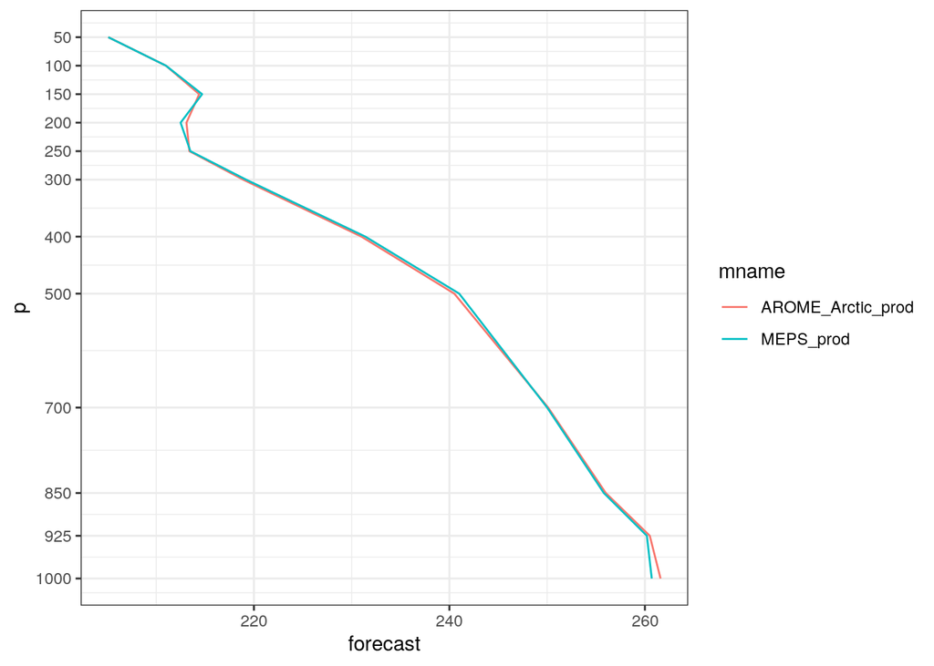

```r
plot_vertical_profile(
  t_upper,
  SID       = 22113,
  fcdate    = 2019021712,
  lead_time = 24
)
```

You can also plot the profiles on skew-t / log P grid by setting `skew_t = TRUE`. However, it should be noted that temperatures need to be in °C rather than Kelvin. We can convert the units by using `scale_point_forecast`.

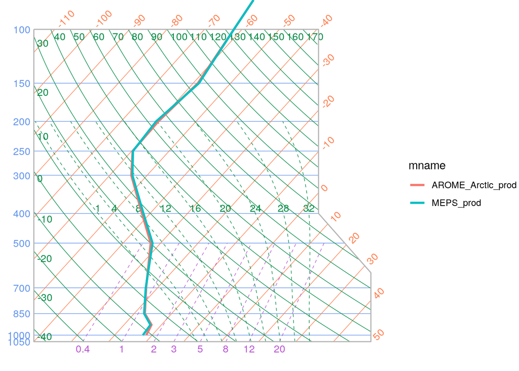

```r
scale_point_forecast(t_upper, -273.15, new_units = "degC") %>%
  plot_vertical_profile(
    SID       = 22113,
    fcdate    = 2019021712,
    lead_time = 24,
    skew_t    = TRUE
  )
```

Your turn:

- You can specify more than 1 station, date, and / or lead time in `plot_vertical_profile`. Experiment with making some multi panel plots.
- Can you figure out how you would add the dew point temperature to the plots?

Solution

- Experiment with making some multi panel plots.

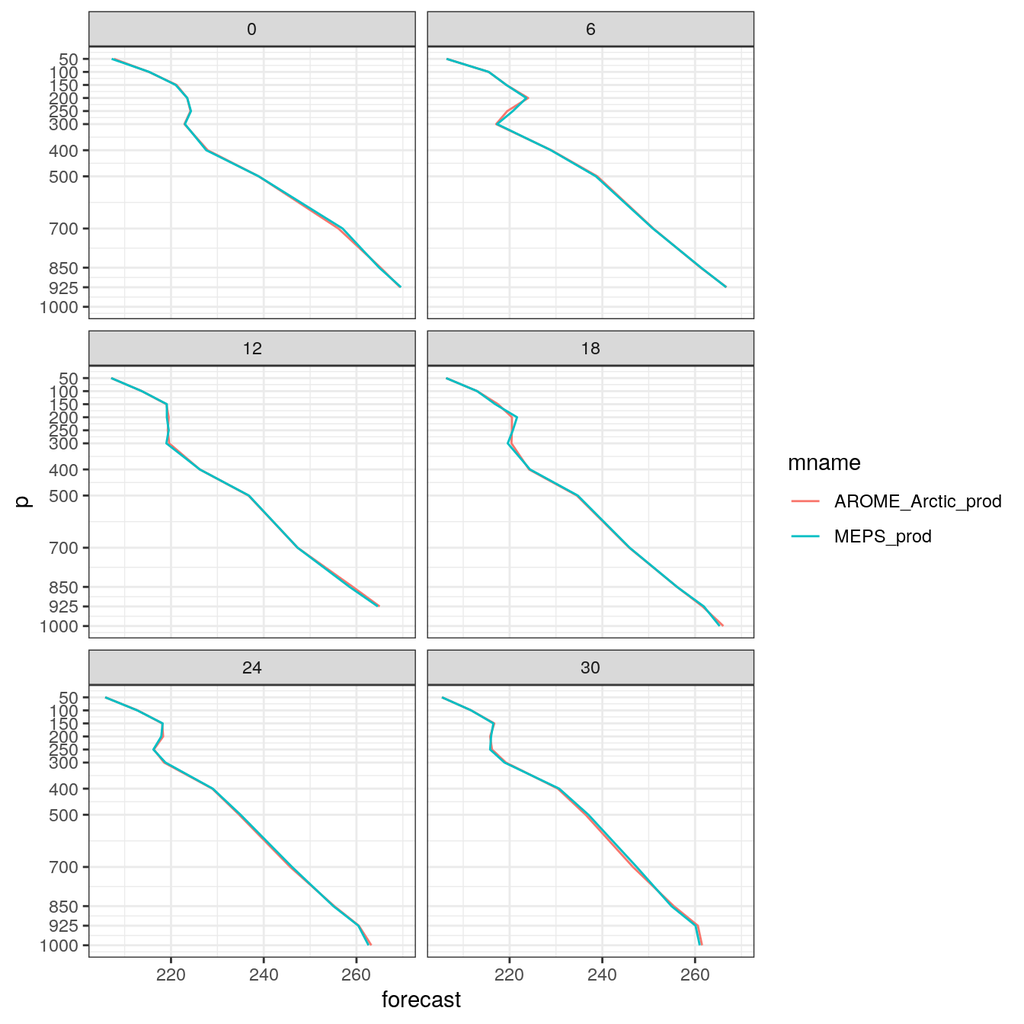

```r
plot_vertical_profile(
  t_upper,
  SID       = 22113,
  fcdate    = 2019021700,
  lead_time = seq(0, 30, 6),
  facet_by  = vars(leadtime)
)
```

- Can you figure out how you would add the dew point temperature to the plots?

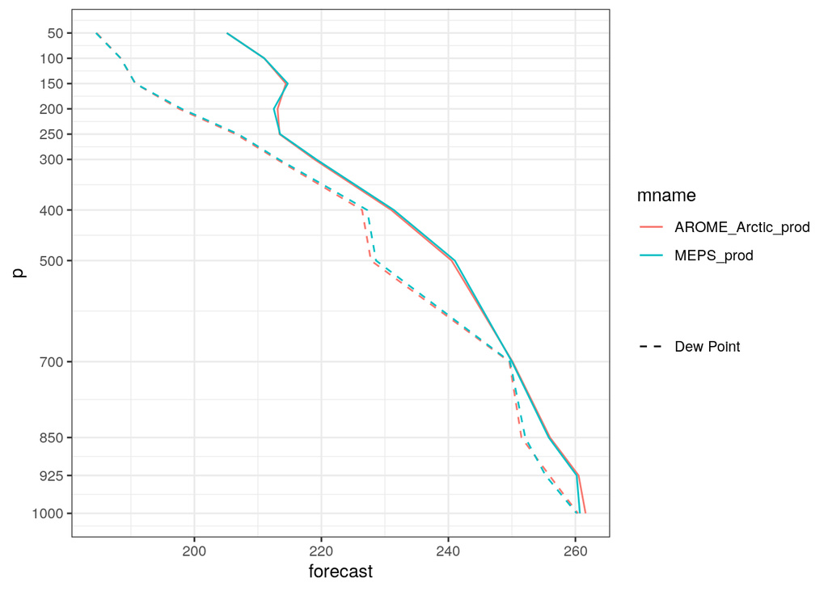

```r
plot_vertical_profile(
  t_upper,
  SID       = 22113,
  fcdate    = 2019021712,
  lead_time = 24
) +
  geom_path(
    data = filter(
      bind_fcst(td_upper),
      SID      == 22113,
      fcdate   == str_datetime_to_unixtime(2019021712),
      leadtime == 24
    ),
    aes(linetype = "Dew Point")
  ) +
  scale_linetype_manual("", values = 2)
```